# DATASCI 350 - Data Science Computing

Lecture 15 - Cloud Computing II

Danilo Freire

danilo.freire@emory.edu

Department of Data and Decision Sciences  
Emory University

# Hello, everyone! 👋

# Brief recap 📚

## Introduction to cloud computing and AWS

- Cloud computing fundamentals:
  - On-demand resource delivery with pay-as-you-go pricing models
  - Elastic scalability, measured service, resource pooling
  - Service models: IaaS (virtualisation), PaaS (managed platforms), SaaS (full applications)
- Enterprise case studies:
  - Animoto: Scaled from 50 to 3,500 EC2 instances during viral Facebook app growth
  - Washington Post: Processed 17,481 pages of Clinton schedules in 9 hours using 200 EC2 instances

| On-premise | IaaS | PaaS | SaaS |
| --- | --- | --- | --- |
| Application | Application | Application | Application |
| Middleware | Middleware | Middleware | Middleware |
| OS | OS | OS | OS |
| Virtualisation | Virtualisation | Virtualisation | Virtualisation |
| Servers | Servers | Servers | Servers |
| Networking | Networking | Networking | Networking |

User manages  
Provider manages

## Introduction to cloud computing and AWS

- AWS architecture components:
  - EC2: Resizable compute capacity with auto-scaling
  - S3: 11x9s durability object storage with lifecycle policies
  - RDS: Managed relational databases (PostgreSQL/MySQL, etc.)
  - SageMaker: ML workflows with Jupyter integration
- Cost management:
  - Always configure billing alarms and budget limits!
  - Monitor data transfer costs and storage class transitions

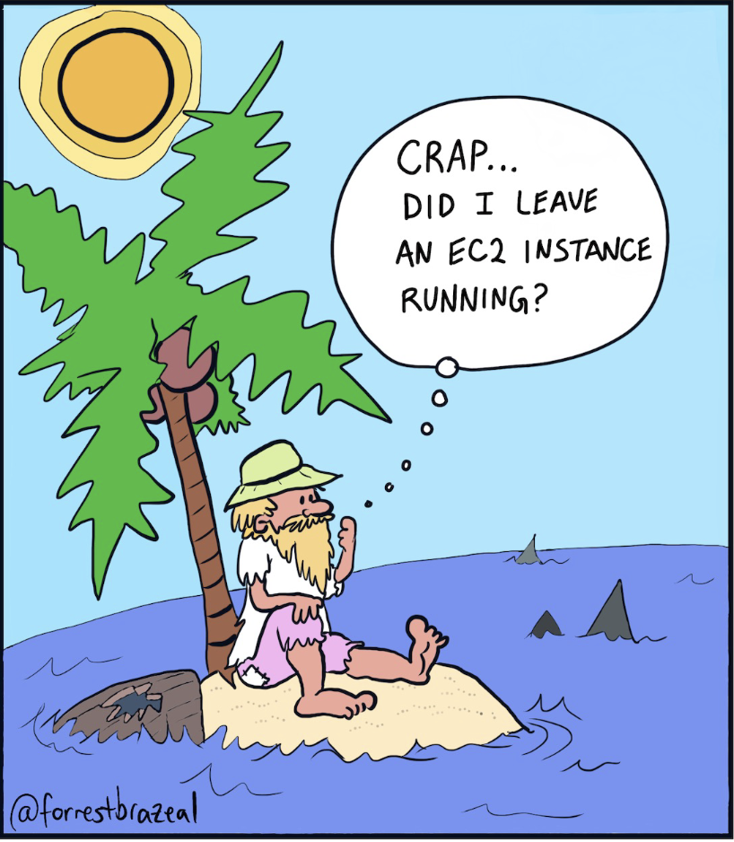

# Today’s plan 📅

## Today’s plan

- Using EC2 instances from your local machine
  - Launching instances via AWS Console
  - Connecting via SSH with key pairs
- Essential Linux commands for instance management:
  - Package management: `apt update`, `apt upgrade`, `apt install`
  - File operations: `scp` and `chmod`
- Activity 01: Launching a Jupyter notebook on an EC2 instance
  - Installing Jupyter and running a Python script
  - Forwarding ports with SSH
  - Running Jupyter on a remote server
- Activity 02: Data analysis on the cloud (time permitting)
  - Creating a weather dataset and uploading it to an EC2 instance
  - Analysing the data with Python and downloading the results

[figure not shown]

[About Ubuntu (Wikipedia)](https://en.wikipedia.org/wiki/Ubuntu)

[Ubuntu (Official Site)](https://ubuntu.com/)

# EC2 from your local machine 🖥️

## EC2 instances in a nutshell

- Just to recap: EC2 is a virtual server in the cloud
- Each instance has a full OS and can run any software
  - The vast majority of instances run Linux ([Ubuntu](https://ubuntu.com/), [Amazon Linux](https://aws.amazon.com/linux/amazon-linux-2023/), etc.)
- Virtualisation allows multiple instances on the same hardware
  - A [virtual machine](https://www.datacamp.com/blog/what-is-a-virtual-machine) is a software emulation of a physical computer
  - [Hypervisors](https://www.redhat.com/en/topics/virtualization/what-is-a-hypervisor) manage VMs and allocate resources
- Instance types vary in CPU, memory, storage, and network capacity
  - T2 instances are general-purpose, M5 are memory-optimised, etc
  - You can change instance types on-the-fly
- The [free tier](https://aws.amazon.com/free/) offers 750 hours of t2.micro instances per month, 1 GB of RAM, and 30 GB of storage

[figure not shown]

Source: [DataCamp](https://www.datacamp.com/blog/what-is-a-virtual-machine)

## Ubuntu Linux

- Linux is a popular open-source operating system
- They are popular precisely because they are free, but they are also more secure than Windows and can be customised to your needs (in contrast to MacOS)
- The most widely used Linux distribution is [Ubuntu](https://ubuntu.com/)
  - [Debian](https://www.debian.org/)-based, with a focus on usability and security
  - [Long-term support (LTS)](https://ubuntu.com/about/release-cycle) versions are supported for 5 years
  - [Desktop](https://ubuntu.com/desktop) and server editions available
- [Google](https://cloud.google.com/), [Amazon](https://aws.amazon.com/), and [Microsoft](https://azure.microsoft.com/en-us/) all offer Ubuntu instances
- [Windows Subsystem for Linux (WSL)](https://docs.microsoft.com/en-us/windows/wsl/) allows you to run Ubuntu on Windows
- For our purposes, we will use Ubuntu instances on AWS

[figure not shown]

[Ubuntu Desktop](https://ubuntu.com/desktop)

- All Linux distributions share a common set of commands and use bash as the default shell
- Therefore, all commands we have learnt so far will work on Ubuntu

## Ubuntu server

- While Ubuntu is a complete OS (with a GUI), we will use the terminal to interact with our instances
- Why should we only use the terminal?
  - A bare-bones Ubuntu instance is cheaper and faster than a full desktop
  - And as you already know, the terminal has everything you need to manage your instance and run your code
- Again, all commands are the same (`ls`, `cd`, `pwd`, etc)
- However, you have to use `sudo` to run commands as root (superuser)
  - This is because root has full control over the system and can do anything
  - Be careful with root!
- To install software, use `apt` (Advanced Package Tool)
- `apt update` refreshes the package list
- `apt install` installs a package

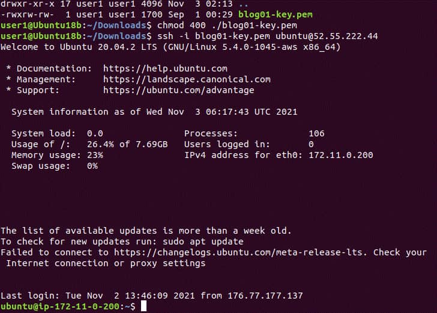

[Ubuntu Terminal](https://ubuntu.com/tutorials/command-line-for-beginners)

- `sudo apt install python3` installs Python 3
- `sudo apt install python3-pip` installs [pip](https://pypi.org/project/pip/)

## Windows Subsystem for Linux (WSL)

- [WSL](https://docs.microsoft.com/en-us/windows/wsl/) is nothing but Ubuntu running natively on Windows!
- I hope many of you have already installed it! 😊
- If you work with WSL, make sure to store your SSH key file in your Ubuntu home directory
- That’s because Windows FS does not work well with `chmod 400` (which is required to set the correct permissions on your key file)
- To locate your `/home/user` directory, type `cd ~` and then `pwd` in your WSL terminal
- You can then move your key file there using Windows Explorer or the `mv` command in WSL

[figure not shown]

[Ubuntu on Windows (WSL)](https://ubuntu.com/wsl)

## Step 01: Launching an EC2 instance

- Now we are ready to launch an EC2 instance!
- Go to the AWS Console: https://aws.amazon.com/console/, sign in, and click on (search for) EC2
- You will see the EC2 Dashboard, with a big orange button saying “Launch Instance”
- Click on it, and you will be taken to the [AMI (Amazon Machine Image)](https://docs.aws.amazon.com/AWSEC2/latest/UserGuide/AMIs.html) selection page
- There, we will choose an Ubuntu AMI (free tier eligible)
- Amazon has thousands of AMIs available, including Windows, macOS, and other Linux distributions
- Many are already pre-configured to run specific software (e.g. [Jupyter](https://jupyter.org/), [TensorFlow](https://www.tensorflow.org/), [Docker](https://www.docker.com/), etc.)

[figure not shown]

[EC2 Dashboard](https://us-east-1.console.aws.amazon.com/ec2/home?region=us-east-1#Home:)

## Step 02: Choosing an instance type

- Type a name to label your VM under `Name and tags`. For example, name your instance `datasci350`
- I recommend using `Ubuntu Server 24.04 LTS` as the OS image and `64-bit (x86)` as the architecture
- You can also specify the number of instances to launch at this time. To start off, choose 1
- Next choose an EC2 instance type
- To test, you can always create one or multiple `t2.micro` or `t1.micro`, both of which are free tier eligible
- If you need more power, you can always change the instance type later
- So far, so good? 😊

[figure not shown]

[Instance Type](https://us-east-1.console.aws.amazon.com/ec2/v2/home?region=us-east-1#LaunchInstanceWizard:)

## Step 03: Choose an SSH key pair

- Next, you will be asked to choose a key pair
- You just have to [do it once](https://docs.aws.amazon.com/AWSEC2/latest/UserGuide/ec2-key-pairs.html), and then you can use the same key pair for all your instances
- A key pair is a pair of cryptographic keys that you use to authenticate to an instance
- Click on `Create a new key pair` and give it a name (e.g. `datasci350`)
- Choose `ED25519` and `.pem` as the file format
- Click on `Create Key Pair` and save it to a secure location
- It is important to keep this key safe and know where it is, as it is the only way to access your instance

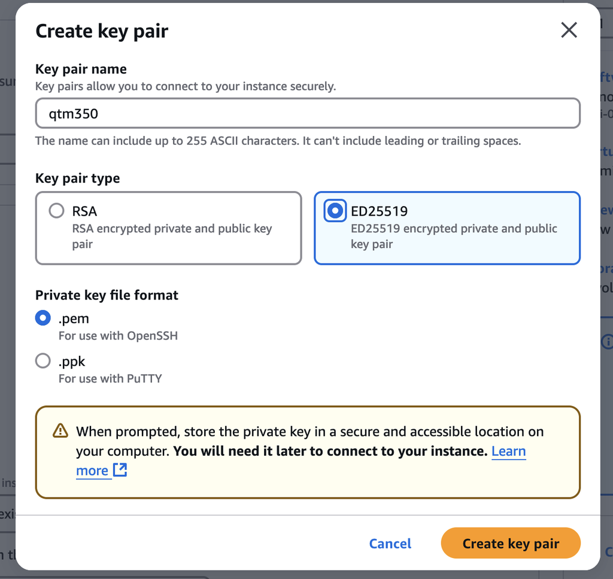

## Step 04: Check HTTP/HTTPS options

- Under `Network settings`, you may check `Allow HTTPS traffic from the internet` and `Allow HTTP traffic from the internet` so that you can access the web servers hosted on your EC2 VM
- We will allow all traffic for now, but in a production environment, you should restrict traffic to only what is necessary
- Why so? Security! The more open ports you have, the more vulnerable your instance is to attacks
- You can always edit the security group later to add or remove rules

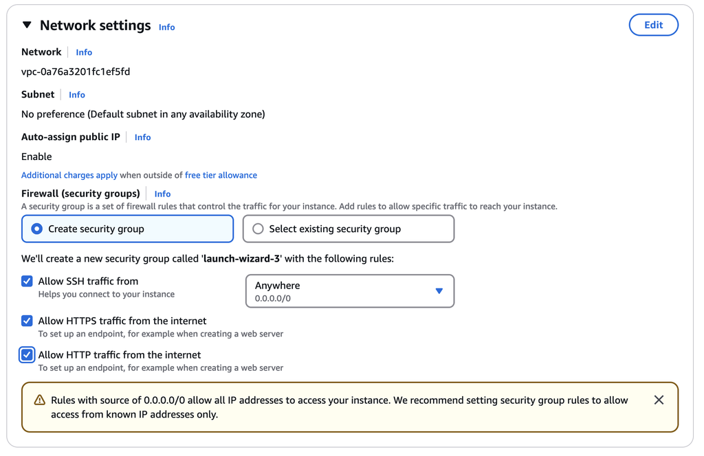

## Step 05: Configure storage

- You may also increase the storage capacity of the `Root` volume under Configure storage
- By default you will be allocated a small 8-GB root disk
- The free tier gives you 30 GB of storage, but 8 GB is usually enough for testing and learning purposes
- You can also add additional volumes if you need more storage
- `gp3` is the default volume type, and it works fine for most use cases
- `io2` is the fastest and most expensive volume type, usually used for high-performance databases (which require millisecond latency)
- If you have data that is not frequently accessed, you can use `sc1` or `st1` for cost savings

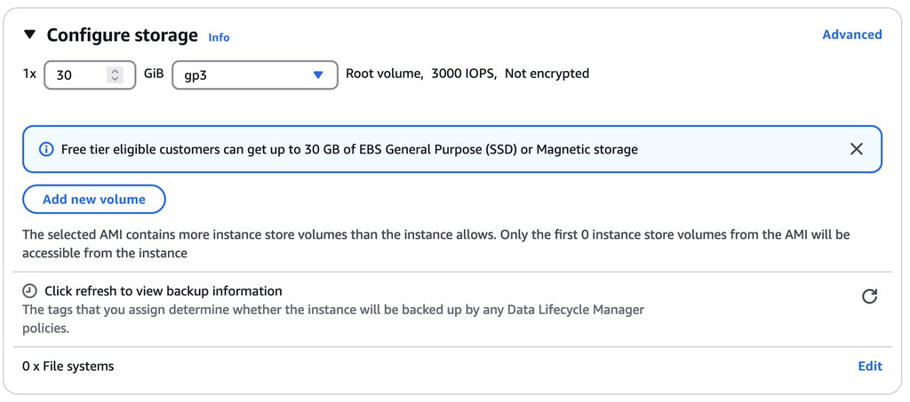

- Now you just have to click on `Launch instance`! 🚀

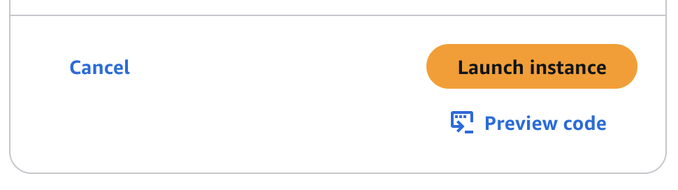

## Step 06: Log in to the EC2 instance through SSH

- Once you click on `Launch`, you will be taken to the Instances page
- Click on `Connect to instance` to see the instructions

[figure not shown]

- Click on `SSH client` to see the command to connect to your instance
- Open a terminal on your local machine and navigate to the directory where you saved the key pair
- Run the `chmod 400 "name-of-your-key.pem"` and the `Example` commands provided by AWS to connect to your instance (`ssh -i "name-of-your-key.pem" ubuntu@public-ip`)

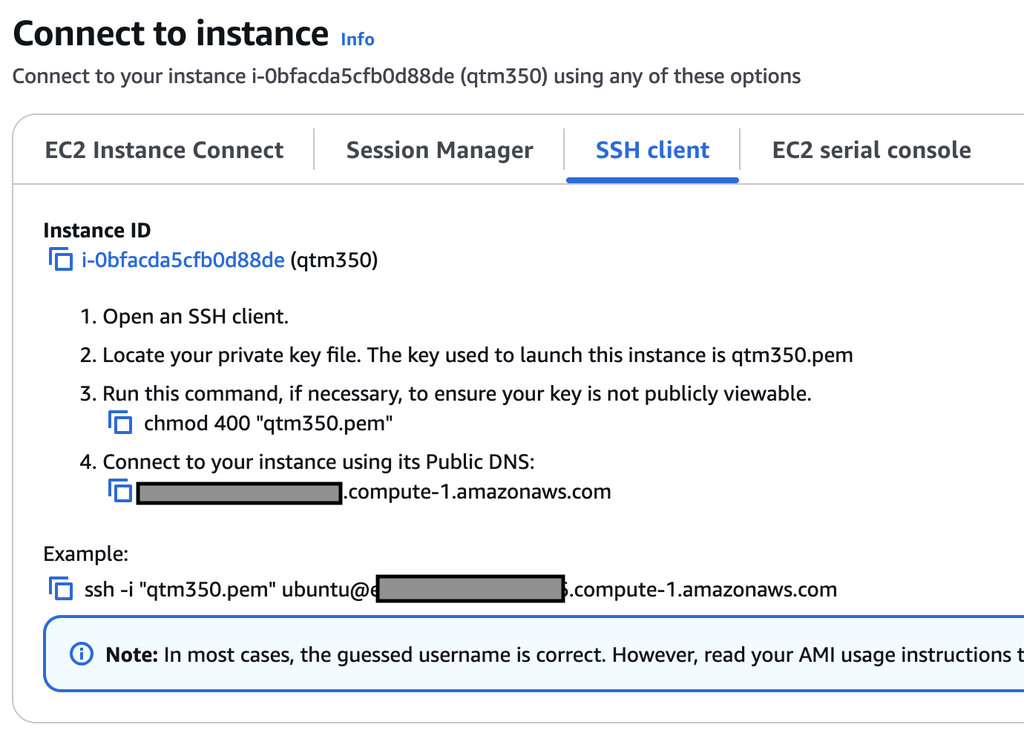

## And you are in! 🎉

### Welcome to the cloud! 🌥️

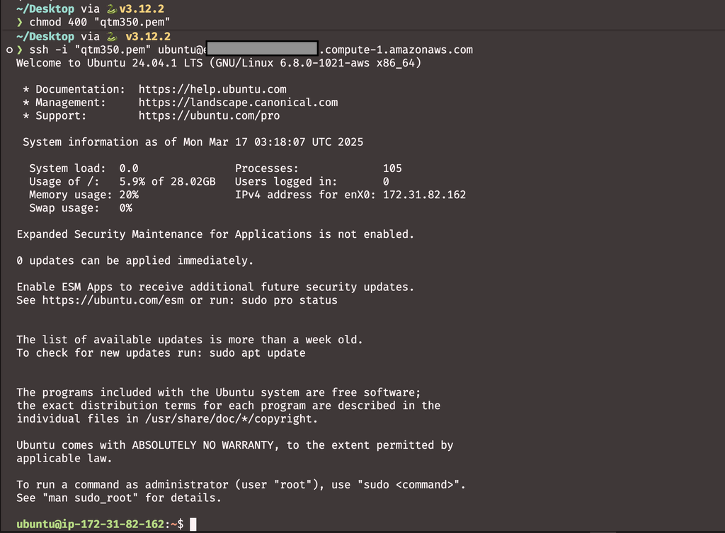

## Check the instance details on the AWS Console

- You can click on the instance ID or on the `Instances` link on the left to see the details of your instance
- You can see the public IP address of your instance, the instance type, the security group, the key pair, and other details
- You can also stop, terminate, or reboot your instance from this page (we will see how to do this later)

[figure not shown]

## Using CloudShell

- If you don’t have access to a terminal, you can use [CloudShell](https://aws.amazon.com/cloudshell/)
- CloudShell is a browser-based shell that you can use to run commands on your instances
- You can find it on the AWS Console, in the bottom left corner
- It is a great way to run commands on your instances without having to install anything on your local machine
- You can also use it to run commands on your S3 buckets, RDS databases, and other AWS services
- I recommend using your local terminal as you can write code in your local IDE and run it on the cloud
- But it is nice that AWS provides this option

[figure not shown]

## Step 07: Update and install software

- Once you are in, the first thing you should do is to update the package list
- Run `sudo apt update` to refresh the package list
- Then, type `sudo apt upgrade` to install the latest updates
  - You can use the `-y` flag to automatically answer `yes` to all prompts, e.g., `sudo apt update && sudo apt upgrade -y`
- You can also install software using `sudo apt install`
- For example, to install Python 3, run `sudo apt install python3`
- To install pip, run `sudo apt install python3-pip`
- You can also install [Jupyter](https://jupyter.org/) or any other software you need
- And we will be ready to go! 🚀

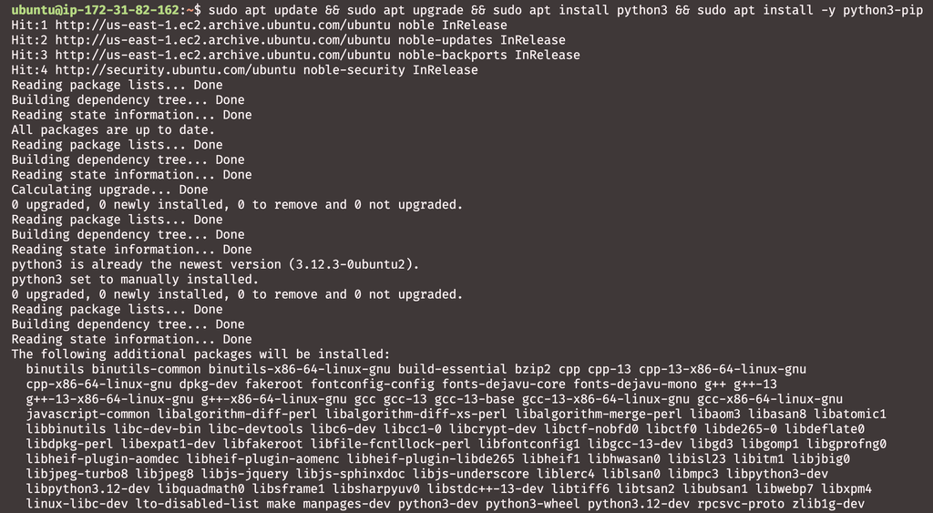

`sudo apt update && sudo apt upgrade -y && sudo apt install -y python3 && sudo apt install -y python3-pip`

## Adding files to your instance

- You can add files to your instance using `scp` (secure copy)
- `scp` is a command-line tool that allows you to copy files securely
- The `-i` flag (“identity file”) specifies which private key file to use for authentication (the `.pem` file you downloaded when creating the key pair)
- To copy a file from your local machine to your instance, run `scp -i "name-of-your-key.pem" file-to-copy ubuntu@public-ip:/path/to/destination`
- To copy a file from your instance to your local machine, run `scp -i "name-of-your-key.pem" ubuntu@public-ip:/path/to/file-to-copy /path/to/destination`
- You can also use `scp` to copy files between two remote servers
- Windows users can use [WinSCP](https://winscp.net/eng/index.php) or [PuTTY](https://www.putty.org/)
- Open a new bash/zsh local terminal (**not the one you are using to connect to your instance!**) and type the following (one line at a time):

```
echo "print('Hello, DATASCI350!')" > hello.py
scp -i qtm350.pem hello.py ubuntu@XXXXXX.compute-1.amazonaws.com:~
```

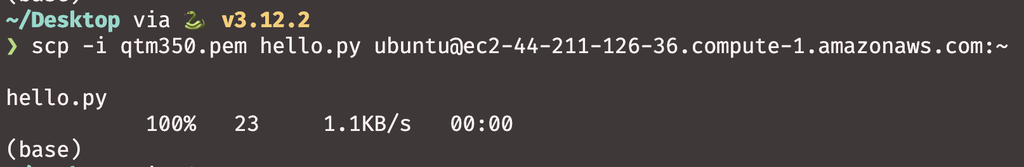

- Don’t forget to replace `XXXXXX` with your public IP and note that `:~` is your home directory on the instance. Don’t forget to add it!
- You can find your public IP on the AWS Console, on the Instances page. It’s the same you copied in the “Example” command when connecting via SSH
- You can check (`ls`) and run (`python3`) the file on your instance

[figure not shown]

## Stopping and terminating your instance

- It is very important to stop or terminate your instance when you are not using it
- Stopping an instance will pause it and you will not be charged for it (but you will be charged for the storage)
- Terminating an instance will delete it and you will not be charged for it (but you will lose all data)
- You can stop or terminate your instance from the Instances page on the AWS Console
- You can also reboot your instance if it is not responding
- So let’s terminate our instance now! 🛑

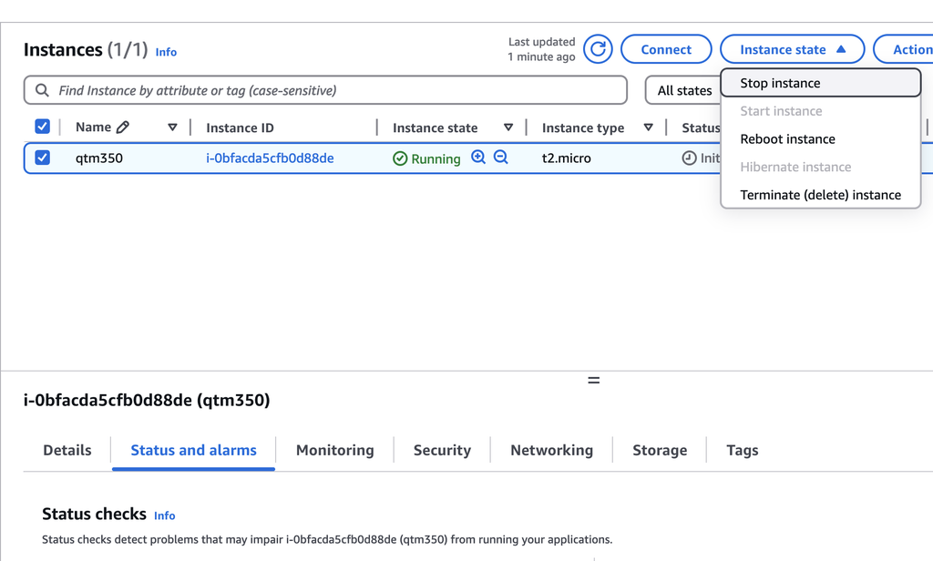

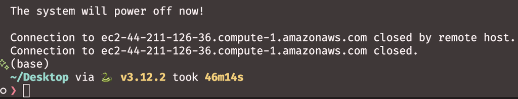

# Now it is your turn! 🚀

## Activity 01

1. Create an EC2 instance on AWS called `jupyter` (as we did in the previous slides)
2. Connect to your instance with port forwarding from your local terminal:
   - `ssh -i "<your-key>.pem" ubuntu@<public_IPv4_DNS_address> -L 8000:localhost:8888`
   - The `-L 8000:localhost:8888` part forwards port 8888 on the instance to port 8000 on your machine
3. Update, upgrade, and install Python 3, pip, and Jupyter:
   - `sudo apt update && sudo apt upgrade -y`
   - `sudo apt install -y python3 python3-pip python3-notebook`
   - `source ~/.profile`
4. Check that everything is installed: `which python3`, `which pip3`, `which jupyter`
5. Start Jupyter: `jupyter notebook`
6. Open your browser and go to `http://localhost:8000`. Copy the token from the terminal to log in
   - You can also click the link in the terminal (it looks like `http://localhost:8888/?token=...`) and change `8888` to `8000`
7. Create a new notebook and run `print('Hello, DATASCI350!')` (or any other code you like!)
8. Do not terminate your instance, we will use it later

## Activity 01

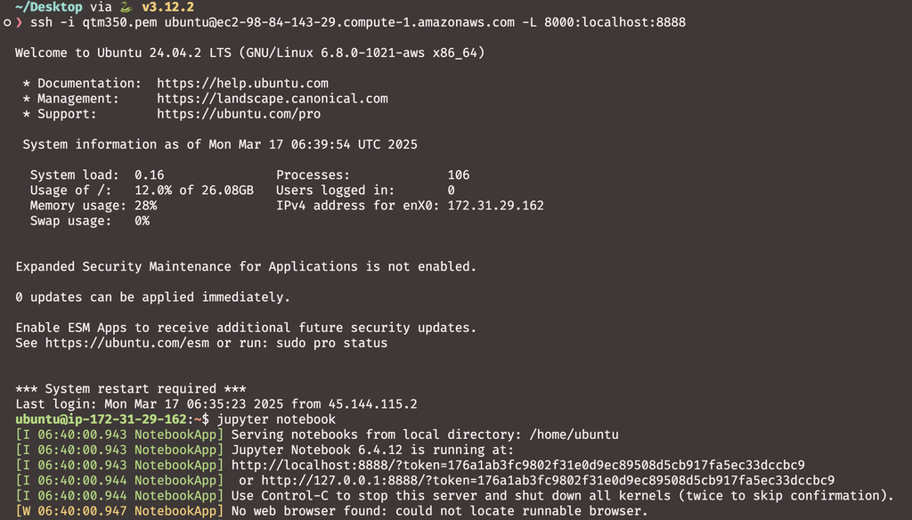

## Activity 01

[figure not shown]

# Another one? 🚀

## Activity 02

- Now that you have your EC2 instance running, let’s do some data analysis
- We will practise two ways of getting files onto your instance:
  - **Method 1 (`scp`)**: Create a file on your local machine, then upload it to the instance. Use this when you have files on your own computer that are not available online (e.g., your own datasets, private code)
  - **Method 2 (`wget`)**: Download a file directly from the internet to the instance. Use this when the file is already hosted somewhere (e.g., GitHub, a public dataset URL). This skips your local machine entirely
- First, install the required packages on your instance:
  - `sudo apt install -y python3-numpy python3-pandas python3-matplotlib python3-seaborn`
- **Method 1: local to cloud with `scp`.** On your local machine, create a weather dataset with the Python code below, or download it here: weather_data.py

```python
# weather_data.py
import pandas as pd
import numpy as np
import datetime

# Set seed for reproducibility
np.random.seed(42)

# Generate dates for the past 30 days
dates = pd.date_range(end=datetime.datetime.now(), periods=30).tolist()
dates = [d.strftime('%Y-%m-%d') for d in dates]

# Generate temperature data with some randomness
temp_high = np.random.normal(75, 8, 30)
temp_low = temp_high - np.random.uniform(10, 20, 30)
precipitation = np.random.exponential(0.5, 30)
humidity = np.random.normal(65, 10, 30)

# Create a structured dataset
weather_data = pd.DataFrame({
    'date': dates,
    'temp_high': temp_high,
    'temp_low': temp_low,
    'precipitation': precipitation,
    'humidity': humidity
})

# Save to a text file
with open('weather_data.txt', 'w') as f:
    f.write("# Weather data for the past 30 days\n")
    f.write(weather_data.to_string(index=False))

print("Weather data saved to weather_data.txt")
```

## Activity 02

- Run this script on your local machine: `python3 weather_data.py`
- It will create a file called `weather_data.txt` with 30 days of weather data
- Now upload it to your EC2 instance using `scp` (from a local terminal):
  - `scp -i <your-key>.pem weather_data.txt ubuntu@<your-instance-ip>:~/`
- You can verify it arrived by running `ls` on your instance
- **Method 2: internet to cloud with `wget`.** Now let’s get the analysis script directly on the instance, without going through your local machine. Run this on your EC2 instance:
- `wget https://raw.githubusercontent.com/danilofreire/datasci350/main/lectures/lecture-15/weather_analysis.py` (one line)
- The code is shown below for reference (you don’t need to copy it, `wget` already downloaded it):

```python
# weather_analysis.py
import pandas as pd
import matplotlib.pyplot as plt
import seaborn as sns
from io import StringIO  # Add proper import for StringIO

# Read the weather data
with open('weather_data.txt', 'r') as f:
    lines = f.readlines()

# Skip the header comment
data_str = ''.join(lines[1:])
df = pd.read_csv(StringIO(data_str), sep=r'\s+')  # Fix StringIO import and use raw string for regex

# Print basic statistics
print("Weather Data Analysis:")
print("=====================")
print(f"Number of days: {len(df)}")
print(f"Average high temperature: {df['temp_high'].mean():.1f}°F")
print(f"Average low temperature: {df['temp_low'].mean():.1f}°F")
print(f"Maximum temperature: {df['temp_high'].max():.1f}°F on {df.loc[df['temp_high'].idxmax(), 'date']}")
print(f"Minimum temperature: {df['temp_low'].min():.1f}°F on {df.loc[df['temp_low'].idxmin(), 'date']}")
print(f"Days with precipitation > 1 inch: {len(df[df['precipitation'] > 1])}")

# Create a visualisation
plt.figure(figsize=(12, 6))
sns.set_style("whitegrid")

# Plot temperature range
plt.fill_between(df['date'], df['temp_low'], df['temp_high'], alpha=0.3, color='skyblue')
plt.plot(df['date'], df['temp_high'], marker='o', color='red', label='High Temp')
plt.plot(df['date'], df['temp_low'], marker='o', color='blue', label='Low Temp')

# Add precipitation as bars on a secondary axis
ax2 = plt.twinx()
ax2.bar(df['date'], df['precipitation'], alpha=0.3, color='navy', width=0.5, label='Precipitation')
ax2.set_ylabel('Precipitation (inches)', color='navy')
ax2.tick_params(axis='y', labelcolor='navy')

# Formatting
plt.title('30-Day Weather Report: Temperature Range and Precipitation', fontsize=16)
plt.xticks(rotation=45, ha='right')
plt.ylabel('Temperature (°F)')
plt.legend(loc='upper left')
plt.tight_layout()

# Save the figure
plt.savefig('weather_analysis.png')
print("Analysis complete. Results saved to 'weather_analysis.png'")
```

## Activity 02

- Both files are now on your instance: `weather_data.txt` (uploaded via `scp`) and `weather_analysis.py` (downloaded via `wget`)
- Run the analysis on your instance: `python3 weather_analysis.py`
- Or, if you prefer, open Jupyter (`jupyter notebook`) and run it there
- Download the resulting image back to your local machine (using `scp` again, from a local terminal):
  - `scp -i <your-key>.pem ubuntu@<your-instance-ip>:~/weather_analysis.png ./`
- View the image on your local machine
- Don’t forget to terminate your instance when done!

**Recap**: we used `scp` to move files between your computer and the instance, and `wget` to download files from the internet directly to the instance. Both are useful in different situations!

## Activity 02 Result

When you run the activity, you should get a weather analysis graph similar to this one:

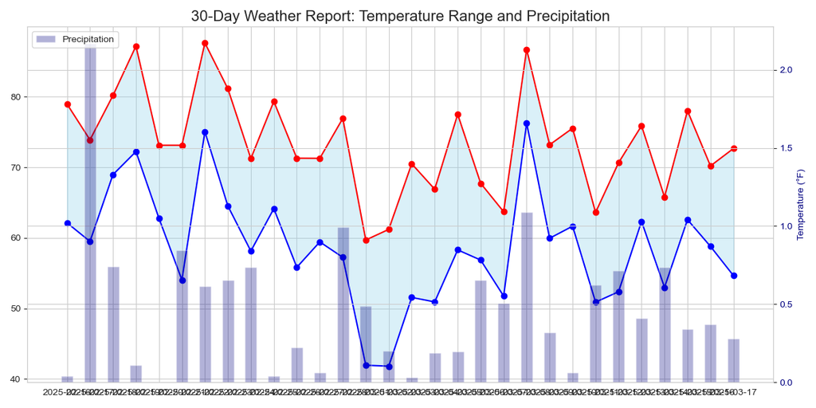

## Activity 02 Result

You’ve just completed a full data analysis workflow in the cloud 🎉

1. Created data locally
2. Uploaded it to the cloud
3. Processed it on a cloud server
4. Generated visualisations
5. Downloaded results to your local machine

This workflow is similar to how data scientists use cloud resources for larger datasets and more complex analyses!

# Conclusion 🎉

## Conclusion

- Today we learnt how to launch an EC2 instance on AWS
- We connected to our instance using SSH and installed software
- We ran a Jupyter notebook on our instance and forwarded the connection to our local machine
- We also uploaded a dataset, analysed it, and downloaded the results
- We learnt how to use scp to copy files between our local machine and our instance
- And we learnt how to stop and terminate our instance
- I hope you enjoyed the class and learnt something new today! 🚀
- But we are just scratching the surface of what you can do with AWS
- Take some time to explore the AWS Console and see what other services are available
  - Lambda is particularly easy and useful, and you can run code without provisioning or managing servers
- You can also explore S3 for object storage, RDS for managed databases, and SageMaker for machine learning
- And remember to always configure billing alarms and budget limits to avoid unexpected charges!

# And that’s a wrap! 🎬